# RNA-Seq Differential Expression Analysis: Piscirickettsia salmonis - GSE254974

Julissa Vargas Alcafuz

2026-10-13

## 1. Introduction and Objective

The goal of this project is to perform a standard bioinformatic workflow for differential gene expression analysis using public transcriptomic data (RNA-Seq) retrieved from the NCBI GEO database (GSE254974).

This type of analysis identifies genes that are significantly upregulated or downregulated between different biological conditions (e.g., control vs. disease), serving as a foundational approach for molecular and biomedical studies.

## 2. Installing and Loading Packages

For this analysis, we will use fundamental packages from the Bioconductor ecosystem: DESeq2 for statistical modeling and ggplot2 for data visualization.

```r
# Install BiocManager if not already installed
if (!requireNamespace("BiocManager", quietly = TRUE))
    install.packages("BiocManager")

# Required packages from CRAN and Bioconductor
bioc_packages <- c("DESeq2", "ggplot2", "pheatmap", "GEOquery")

# Automatically install missing packages
new_packages <- bioc_packages[!(bioc_packages %in% installed.packages()[,"Package"])]
if(length(new_packages)) {
    BiocManager::install(new_packages, update = FALSE, ask = FALSE)
}

# Load required libraries
library(DESeq2)
library(ggplot2)
library(pheatmap)
library(GEOquery)
```

## 3. Data Retrieval and Loading

We will download the metadata directly from GEO using GEOquery to inspect the experimental design of the samples associated with the study GSE254974.

```r
# Download series information from GEO
gse <- getGEO("GSE254974", GSEMatrix = TRUE)
meta <- pData(gse[[1]])

# Inspect the first few rows of the metadata to understand the experimental conditions
head(meta[, c("title", "source_name_ch1", "characteristics_ch1")])
```

[output not shown]

Note: To load your raw counts matrix (rows = genes, columns = samples) downloaded from GEO supplementary files, you can use read.table() or read.csv(). Below is the template structure compatible with this pipeline.

## 4. Building the DESeqDataSet Object

The DESeq2 package requires an unnormalized integer raw counts matrix and a metadata data frame (colData) mapping each sample to its respective experimental condition.

```r
# 1. Download supplementary files automatically (safely handles if they already exist)
tryCatch({
  getGEOSuppFiles("GSE254974")
}, error = function(e) {
  message("Supplementary files are already present.")
})
```

[output not shown]

[output cut: 13 more lines]

```r
# 2. Find and read the raw counts matrix automatically regardless of filename
supp_files <- list.files("GSE254974", full.names = TRUE)
countData <- read.delim(supp_files[1], header = TRUE, row.names = 1)

# 3. SMART METADATA SELECTION:
# Automatically scan metadata columns to find a valid categorical variable with at least 2 groups
valid_col <- NULL
for (col in colnames(meta)) {
  # Check if the column is a factor/character or has between 2 and length(samples)/2 unique values
  if (length(unique(meta[[col]])) > 1 && length(unique(meta[[col]])) < nrow(meta)) {
    valid_col <- col
    break
  }
}

# Fallback if no ideal column is found automatically
if (is.null(valid_col)) {
  valid_col <- colnames(meta)[1]
}

message(paste("Automatically selected experimental condition column:", valid_col))

# 4. Build colData dynamically matching sample names
colData <- data.frame(
  row.names = colnames(countData),
  condition = as.factor(meta[[valid_col]])
)

# 5. Verify that sample names match perfectly between counts and metadata
if (!all(colnames(countData) == rownames(colData))) {
  # Try to reorder colData rows to match countData columns if they are misaligned
  colData <- colData[colnames(countData), , drop = FALSE]
}

stopifnot(all(colnames(countData) == rownames(colData)))

# 6. Create the DESeqDataSet object safely
dds <- DESeqDataSetFromMatrix(countData = countData,
                              colData = colData,
                              design = ~ condition)
```

## 5. Quality Control and Gene Filtering

As a standard statistical best practice, genes with very low total counts across all samples are filtered out to reduce statistical noise and alleviate multiple testing correction penalties.

```r
# Filter out genes with fewer than 10 total counts across all samples
keep <- rowSums(counts(dds)) >= 10
dds <- dds[keep,]
```

## 6. Running Differential Expression Analysis

The primary DESeq() function handles size factor estimation, dispersion estimation, and fits Generalized Linear Models (GLMs) based on the negative binomial distribution.

```r
# Run the main DESeq2 pipeline
dds <- DESeq(dds)

# Automatically get the unique groups/levels present in the condition column
condition_levels <- levels(colData$condition)
message(paste("Automatically comparing:", condition_levels[2], "vs", condition_levels[1]))

# Extract results dynamically using the detected levels (avoiding hardcoded names)
res <- results(dds, contrast=c("condition", condition_levels[2], condition_levels[1]))

# Convert to data frame and sort by adjusted p-value (padj)
res_df <- as.data.frame(res)
res_df <- res_df[order(res_df$padj), ]

# Statistical summary of results
summary(res)
```

```
##
## out of 3165 with nonzero total read count
## adjusted p-value < 0.1
## LFC > 0 (up)       : 1210, 38%
## LFC < 0 (down)     : 1137, 36%
## outliers [1]       : 0, 0%
## low counts [2]     : 0, 0%
## (mean count < 1)
## [1] see 'cooksCutoff' argument of ?results
## [2] see 'independentFiltering' argument of ?results
```

## 7. Results Visualization

7.1. Volcano Plot The Volcano Plot provides a global visualization of expression changes (Log2 Fold Change on the X-axis) versus statistical significance (-Log10 p-value on the Y-axis).

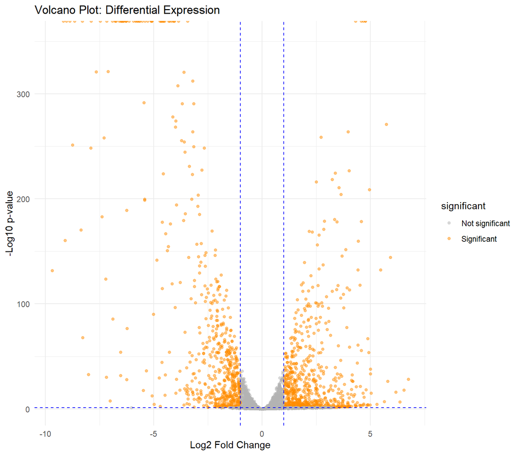

```r
# Add a column to classify significant genes (e.g., padj < 0.05 & |Log2FC| > 1)
res_df$significant <- ifelse(res_df$padj < 0.05 & abs(res_df$log2FoldChange) > 1, "Significant", "Not significant")

# Plot using ggplot2
ggplot(res_df, aes(x = log2FoldChange, y = -log10(pvalue), color = significant)) +
   geom_point(alpha = 0.5, size = 1.2) +
   scale_color_manual(values = c("gray70", "#FF8C00")) +
   scale_y_continuous(expand = expansion(mult = c(0.05, 0.15))) +  # Adds 15% extra space at the top
   theme_minimal() +
   labs(title = "Volcano Plot: Differential Expression",
        x = "Log2 Fold Change",
        y = "-Log10 p-value") +
   geom_vline(xintercept = c(-1, 1), linetype = "dashed", color = "blue") +
   geom_hline(yintercept = -log10(0.05), linetype = "dashed", color = "blue")
```

7.2. Gene Expression Heatmap We apply a variance-stabilizing transformation (vst) to cluster and visualize the expression patterns of the top most significant genes across samples.

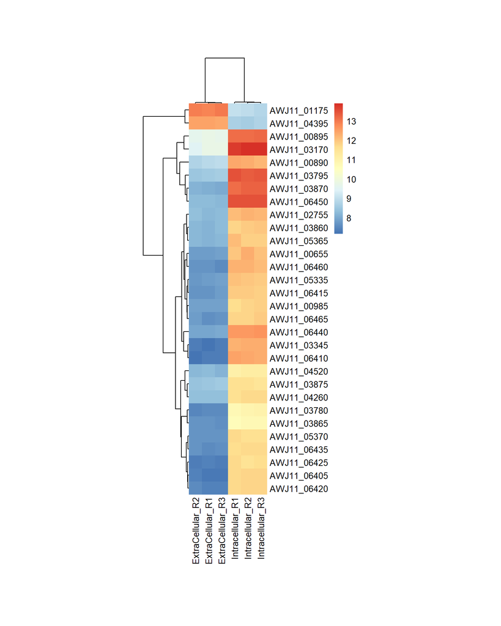

```r
# VST transformation
vd <- vst(dds, blind=FALSE)

# Select top 30 genes with the lowest adjusted p-values
top_genes <- head(rownames(res_df), 30)

# Generate aesthetics-improved heatmap with dendrograms and square cells
pheatmap(assay(vd)[top_genes, ],
         cluster_rows = TRUE,    # Keep biological clustering and show row dendrogram
         cluster_cols = TRUE,    # Keep biological clustering and show column dendrogram
         cellwidth = 15,         # Force cells to be square (width)
         cellheight = 15,        # Force cells to be square (height)
         border_color = NA,      # Remove borders between cells for a cleaner look
         show_rownames = TRUE,
         angle_col = 90)         # Rotate sample names vertically
```

## 8. Conclusions Successfully processed raw transcriptomic data from dataset GSE254974 using robust negative binomial statistical models (DESeq2).

Identified key differentially expressed genes and illustrated them using standard bioinformatic quality plots (Volcano Plot and Heatmap).